# Reproducible Research: Peer Assessment 1

This assignment makes use of data from a personal activity monitoring device. This device collects data at 5 minute intervals through out the day. The data consists of two months of data from an anonymous individual collected during the months of October and November, 2012 and include the number of steps taken in 5 minute intervals each day.

### Data

The data for this assignment can be downloaded from the course web site:

- Dataset: [Activity monitoring data](https://d396qusza40orc.cloudfront.net/repdata%2Fdata%2Factivity.zip) [52K]

The variables included in this dataset are:

- **steps**: Number of steps taking in a 5-minute interval (missing values are coded as `NA`)
- **date**: The date on which the measurement was taken in YYYY-MM-DD format
- **interval**: Identifier for the 5-minute interval in which measurement was taken

## Loading and preprocessing the data

Before loading the data you have to set your working directory (In R) to the directory wich contains activity.csv .e.g. setwd(“C:/Users/Marc/Documents/R_Working_dir”)

The data is being read into df_activity which wil be the dataframe for the first part of this assignment

```r
df_activity<-read.csv("activity.csv")
df_activity$interval<- as.factor(df_activity$interval)
df_activity$date<-as.Date(df_activity$date)
```

### prerequisites

For this assignment libraries dplyr and ggplot2 must be loaded.

```r
library(dplyr)
```

```r
library(ggplot2)
```

## What is mean total number of steps taken per day?

To get an idea of the number of steps made on average per day, we make a histogram in which the number of steps is plotted against the number of days

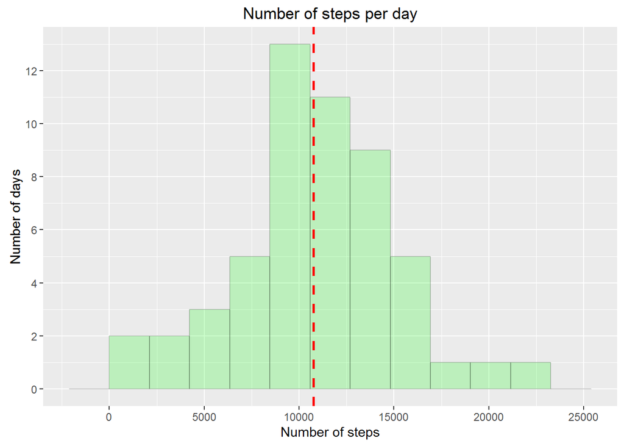

```r
Activity_na<-is.na(df_activity[,1])

groupbyDate <-  df_activity[!Activity_na,]   %>%
    group_by(date) %>%
    summarise(daily_steps=sum(steps))

groupbyDate$daily_steps<-unlist(groupbyDate$daily_steps)

ggplot()+aes(groupbyDate$daily_steps) +
    geom_histogram(col="black",
                   fill="green",
                   alpha = .2,
                   bins=10) +
    labs(title="Number of steps per day") +
    labs(x="Number of steps", y="Number of days") +
    geom_vline(aes(xintercept=mean(groupbyDate$daily_steps)),color="red", linetype="dashed", size=1)+
    scale_x_continuous(breaks = c(0,5000,10000,15000,20000,25000))+
    scale_y_continuous(breaks = c(0,2,4,6,8,10,12,14,16,18,20,22,24,26,28,30))
```

### Extra Barplot

because I felt that the histogram did not give the correct insight, I made a barplot which does give the picture I was looking for

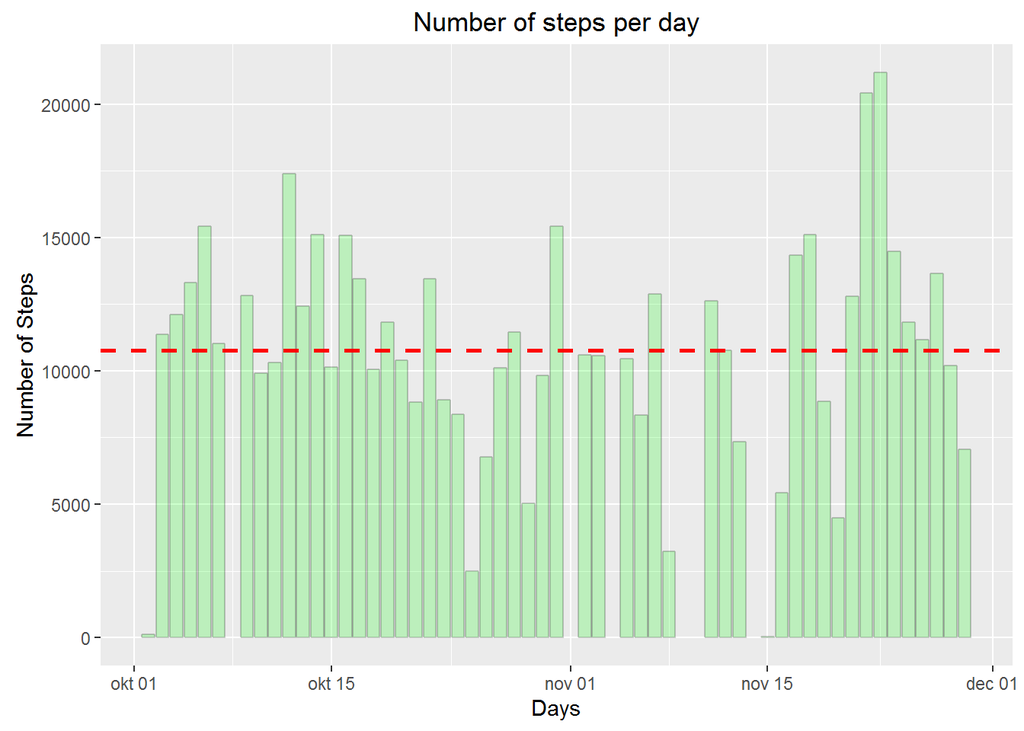

```r
ggplot(groupbyDate)+aes(x=date,y=daily_steps) +
    geom_bar(col="black",
                   fill="green",
                   alpha = .2,
             stat="identity") +
    labs(title="Number of steps per day") +
    labs(x="Days", y="Number of Steps")+
    geom_hline(aes(yintercept=mean(groupbyDate$daily_steps)),color="red", linetype="dashed", size=1)
```

The Mean and median:

```r
mean(groupbyDate$daily_steps)
```

```
## [1] 10766.19
```

```r
median(groupbyDate$daily_steps)
```

```
## [1] 10765
```

## What is the average daily activity pattern?

Here we look at how the distribution of the number of steps throughout the day. The day will be divided into 288 blocks of 5 minutes. NA reccords wil be omitted.

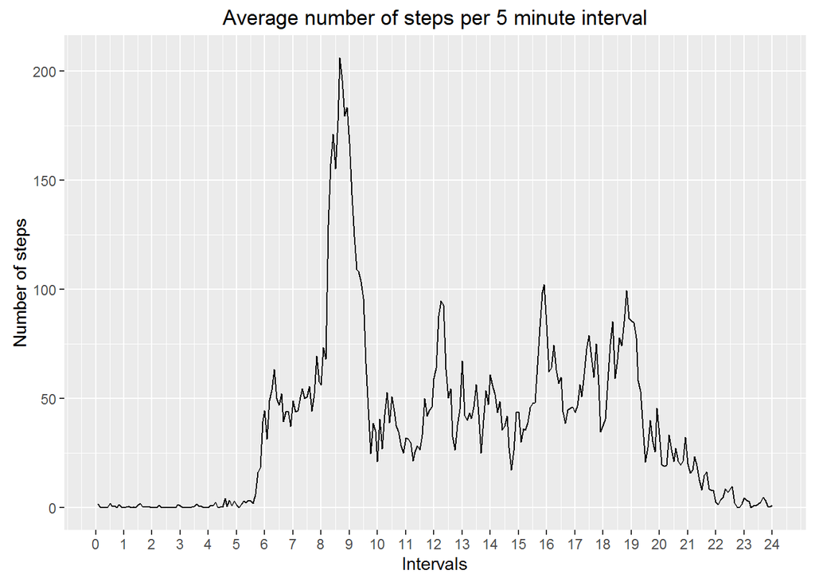

```r
groupbyTime <-  df_activity[!Activity_na,]   %>%
    group_by(interval) %>%
    summarise(interval_steps=mean(steps))

groupbyTime$interval_steps<-unlist(groupbyTime$interval_steps)
groupbyTime$interval_num<-as.numeric(groupbyTime$interval)

ggplot()+aes(groupbyTime$interval_num,groupbyTime$interval_steps) +
    geom_line(col="black") +
    labs(title="Average number of steps per 5 minute interval") +
    labs(x="Intervals", y="Number of steps") +
    scale_x_continuous(breaks=seq(0,288,by=12),labels = seq(0,24))
```

Which block of 5 minutes contains on average the most steps?

```r
groupbyTime[which.max(groupbyTime$interval_steps),"interval"]
```

```
## Source: local data frame [1 x 1]
##
##   interval
##     (fctr)
## 1      835
```

So, between 8:35 and 8:40, on average the most steps are taken…

## Imputing missing values

For all the missing values, the average values of the respective interval wil be used to fill the missing value.

How many missing values do we have?

```r
sum(is.na(df_activity$steps))
```

```
## [1] 2304
```

For all the missing values, the average values of the respective interval wil be used to fill the missing value.

```r
df_activityNOna<-merge(x=df_activity,y=groupbyTime,by="interval",all.x=TRUE)
df_activityNOna[is.na(df_activityNOna[,"steps"]),"steps"]<-round(df_activityNOna[is.na(df_activityNOna[,"steps"]),"interval_steps"])
df_activityNOna<-df_activityNOna[,c("steps","date","interval")]
```

The histogram for the number of steps a day now looks as follows:

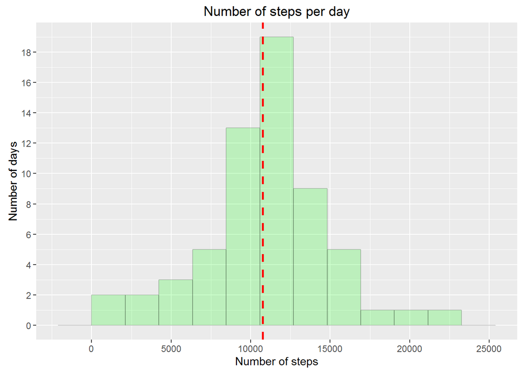

```r
groupbyDateNOna <-  df_activityNOna   %>%
    group_by(date) %>%
    summarise(daily_steps=sum(steps))

groupbyDateNOna$daily_steps<-unlist(groupbyDateNOna$daily_steps)

ggplot()+aes(groupbyDateNOna$daily_steps) +
    geom_histogram(col="black",
                   fill="green",
                   alpha = .2,
                   bins=10) +
    labs(title="Number of steps per day") +
    labs(x="Number of steps", y="Number of days") +
    geom_vline(aes(xintercept=mean(groupbyDateNOna$daily_steps)),color="red", linetype="dashed", size=1)+
    scale_x_continuous(breaks = c(0,5000,10000,15000,20000,25000))+
    scale_y_continuous(breaks = c(0,2,4,6,8,10,12,14,16,18,20,22,24,26,28,30))
```

### Extra Barplot

because I felt that the histogram did not give the correct insight, I made a barplot which does give the picture I was looking for

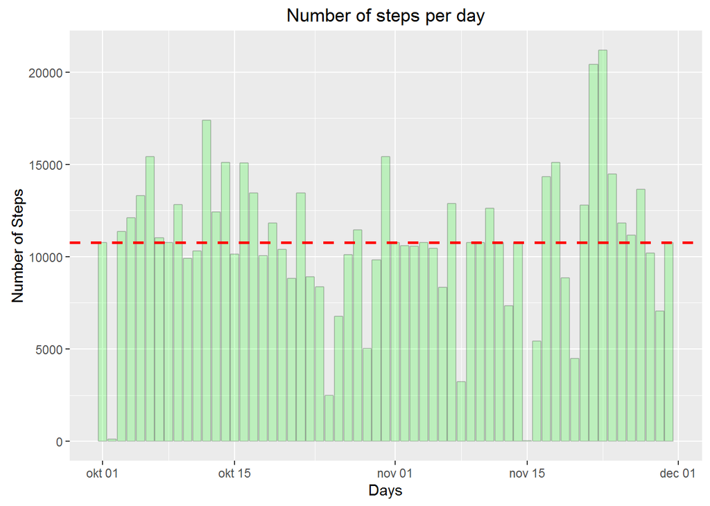

```r
ggplot(groupbyDateNOna)+aes(x=date,y=daily_steps) +
    geom_bar(col="black",
             fill="green",
             alpha = .2,
             stat="identity") +
    labs(title="Number of steps per day") +
    labs(x="Days", y="Number of Steps")+
    geom_hline(aes(yintercept=mean(groupbyDateNOna$daily_steps)),color="red", linetype="dashed", size=1)
```

If you compare this bar plot with the first bar plot it’s clear that days with missing data are filled up to the mean…

Because I added the average number of steps of the missing interval for filling the NA intervals. I don’t expect the average and mean to be changed much

```r
mean(groupbyDateNOna$daily_steps)
```

```
## [1] 10765.64
```

```r
median(groupbyDateNOna$daily_steps)
```

```
## [1] 10762
```

I think the small change in the mean is due to thr round() I used.

## Are there differences in activity patterns between weekdays and weekends?

Here we look at how the distribution of the number of steps throughout the day. The day will be divided into 288 blocks of 5 minutes. But now we split the data into two groups: Weekdays and Weekends

First we introduce a new factorvariable DayType which contains information about the day.. Is it a weekday or a weekend day?

```r
df_activityNOna$DayType<-c("Weekend", "Weekday", "Weekday",
                           "Weekday", "Weekday", "Weekday",
                        "Weekend")[as.POSIXlt(df_activityNOna$date)$wday + 1]
df_activityNOna$DayType<-as.factor(df_activityNOna$DayType)
```

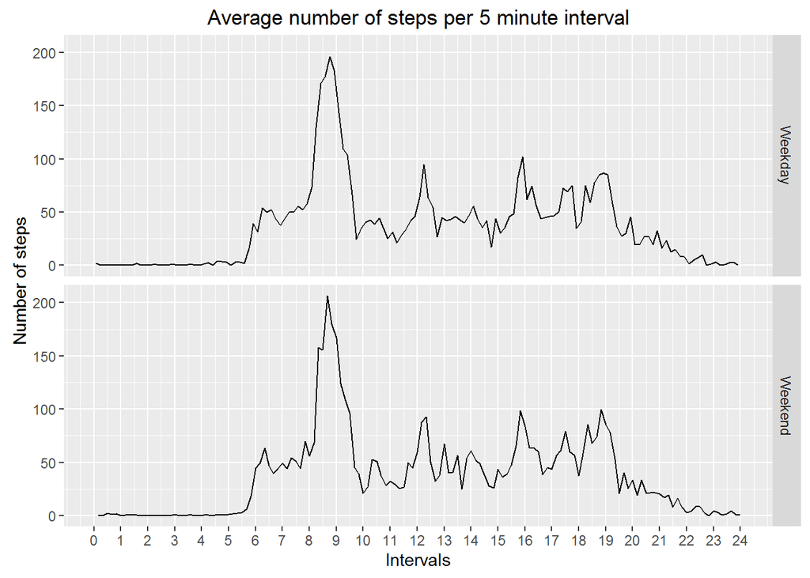

```r
groupbyWDTime <-  df_activityNOna  %>%
    group_by(interval,DayType) %>%
    summarise(interval_steps=mean(steps))

groupbyWDTime$interval_steps<-unlist(groupbyTime$interval_steps)
groupbyWDTime$interval_num<-as.numeric(groupbyTime$interval)

ggplot(groupbyWDTime)+aes(interval_num,interval_steps) +
    geom_line(col="black") +
    labs(title="Average number of steps per 5 minute interval") +
    labs(x="Intervals", y="Number of steps") +
    scale_x_continuous(breaks=seq(0,288,by=12),labels = seq(0,24))+
    facet_grid(DayType ~ . )
```